# Survey Conformal Demo for CANSSI workshop

## Cluster sampling

For equal-probability cluster sampling, we illustrate Dunn’s “subsampling once” method. For each PSU in the calibration set, sample one ultimate unit (school) from that PSU uniformly at random.

This is a simple (although statistically inefficient) way to ensure exchangeability among the calibration and test cases. After subsampling once, each remaining school is exchangeable with the others, and also with the test case if we assume the test case is also chosen by the method “randomly sample one PSU, then randomly select one unit from the chosen PSU.” Thanks to this exchangeability, we can use standard conformal methods on the subsampled calibration residuals.

Dunn et al. provide [R code on GitHub](https://github.com/RobinMDunn/ConformalTwoLayer/) for other conformal methods for hierarchical data, but it is not yet clear how best to apply them with design-based cluster sampling.

```r
# How many school districts (PSUs) are there?
length(unique(apipop$dnum))
```

```
## [1] 757
```

```r
# Aiming for around n=400 ultimate units again,
# let us sample 33 PSUs for model fitting,
# then a calibration set of another 33 PSUs.

# Equivalently, we will instead sample 66 PSUs, then split into 2 folds using `surveyCV`
# (since that is more similar to real survey practice:
#  we would collect the whole dataset first,
#  then split it into training vs calibration *after* data collection)

set.seed(20240609)
clus.PSUs <- sample(unique(apipop$dnum), size = 66)
clus.df <- subset(apipop, dnum %in% clus.PSUs)
# Now we have sampled 66 PSUs, containing a total of 404 schools
length(unique(clus.df$dnum))
```

```
## [1] 66
```

```r
nrow(clus.df)
```

```
## [1] 404
```

```r
# We split them into two folds: training and calibration,
# using surveyCV::folds.svy() which will respect the cluster-sample structure
# (splitting into folds at the PSU level, not ultimate unit level,
#  so that all schools from the same PSU are in the same fold)
folds.clus <- surveyCV::folds.svy(clus.df, nfolds = 2, clusterID = "dnum")

# Save the training set as a survey design object, then fit a svyglm() model
clus.design.train <- svydesign(id = ~dnum, data = clus.df) |>
  subset(folds.clus == 1)
clus.lm.train <- svyglm(api00 ~ meals, design = clus.design.train)
clus.lm.train
```

```
## 1 - level Cluster Sampling design (with replacement)
## With (33) clusters.
## subset(svydesign(id = ~dnum, data = clus.df), folds.clus == 1)
##
## Call:  svyglm(formula = api00 ~ meals, design = clus.design.train)
##
## Coefficients:
## (Intercept)        meals
##     813.144       -3.145
##
## Degrees of Freedom: 164 Total (i.e. Null);  31 Residual
## Null Deviance:       2042000
## Residual Deviance: 827100    AIC: 1880
```

```r
# Save the calibration set as a dataframe
clus.df.calib <- clus.df[folds.clus == 2, ]
# Subsample to one unit per PSU:
# Split by cluster ID (dnum or school district number).
# Then sample one row from each cluster,
#   which creates a list of single-row dataframes.
# Finally, collapse the list into one big dataframe.
clus.df.subsample <-
  split(clus.df.calib, f = ~dnum) |>
  lapply(FUN = function(df) df[sample(nrow(df),1), ]) |>
  do.call(what = "rbind")

# Compute the trained model's predictions (yhat)
#   for each school in the subsample from the calibration set
clus.calib.yhat <- as.vector(predict(clus.lm.train, clus.df.subsample))
# Then save the corresponding absolute residuals:
#   these are our nonconformity scores
clus.calib.absres <- abs(clus.df.subsample$api00 - clus.calib.yhat)

# Now, find the 90% conformal quantile of these absolute residuals;
# this will be the 90% PI half-width or "margin of error" for our conformal PIs.
(clus.confMOE.90 <- q_wtd_conf(y = clus.calib.absres, p = 0.9))
```

```
## [1] 143.4148
```

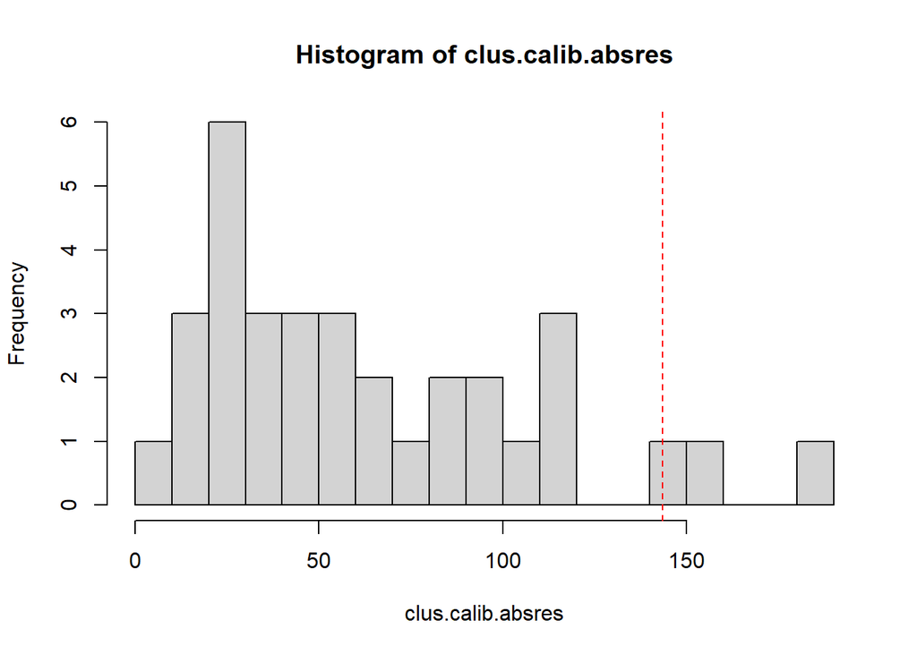

```r
hist(clus.calib.absres, 15)
abline(v = clus.confMOE.90, lty = 2, col = "red")
```

Finally, show our trained-model-plus/minus-PI on a plot of the full population:

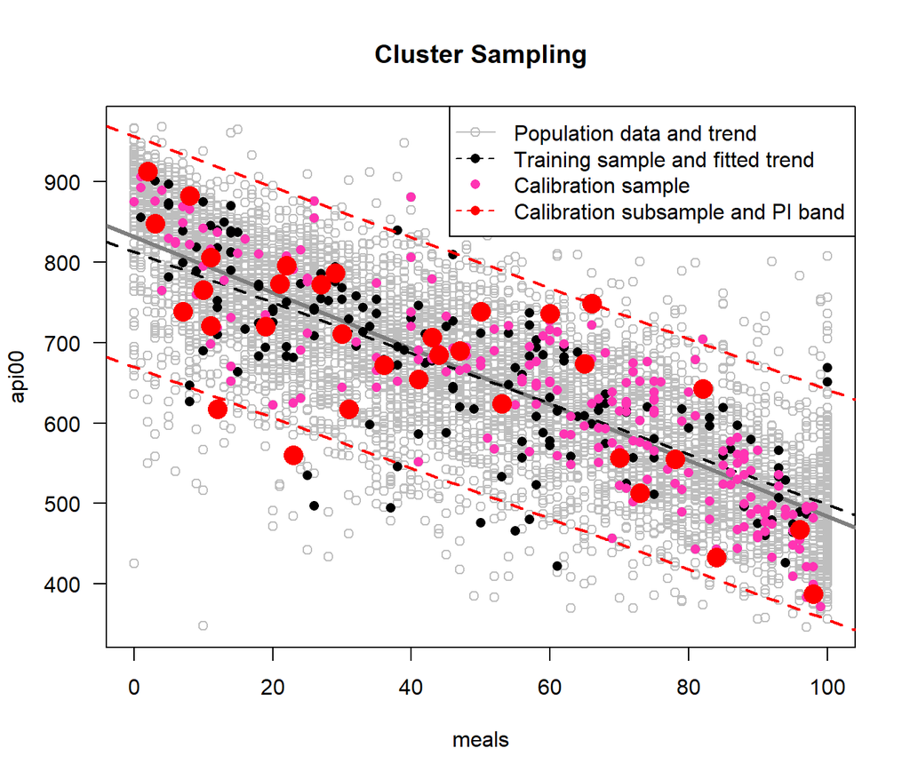

```r
# Finally, show our trained-model-plus/minus-PI on a plot of the full population
with(apipop, plot(meals, api00, col = "grey", las = 1, main = "Cluster Sampling"))
abline(lm(api00 ~ meals, data = apipop), col = "grey50", lwd = 3)
with(clus.design.train$variables, points(meals, api00, col = "black", pch = 16))
abline(clus.lm.train, col = "black", lwd = 2, lty = 2)
with(clus.df.calib, points(meals, api00, col = "maroon1", pch = 16))
with(clus.df.subsample, points(meals, api00, col = "red", pch = 16, cex = 2))
abline(a = clus.lm.train$coefficients[1] - clus.confMOE.90,
       b = clus.lm.train$coefficients[2], col = "red", lwd = 2, lty = 2)
abline(a = clus.lm.train$coefficients[1] + clus.confMOE.90,
       b = clus.lm.train$coefficients[2], col = "red", lwd = 2, lty = 2)
legend("topright",
       legend = c("Population data and trend",
                  "Training sample and fitted trend",
                  "Calibration sample",
                  "Calibration subsample and PI band"),
       lty = c(1,2,NA,2), col = c("grey", "black", "maroon1", "red"), pch = c(1, 16, 16, 16))
```